# Schmidt_Emily_TP1

Emily Schmidt

2024-01-06

**Exercise 1.** In R, call the package TSA. Load the data set hare with data(hare) and plot the data. By looking at the plot, is there a seasonal, trend and/or random component? Is there a cycle?

```
## [1] 50 20 20 22 27 50
```

```
## [1] "ts"
```

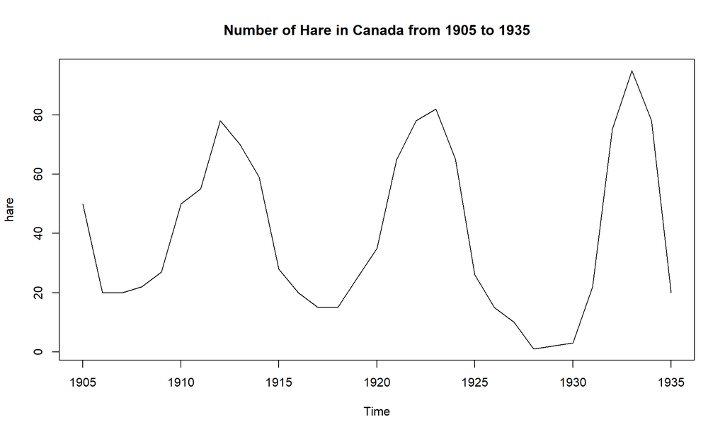

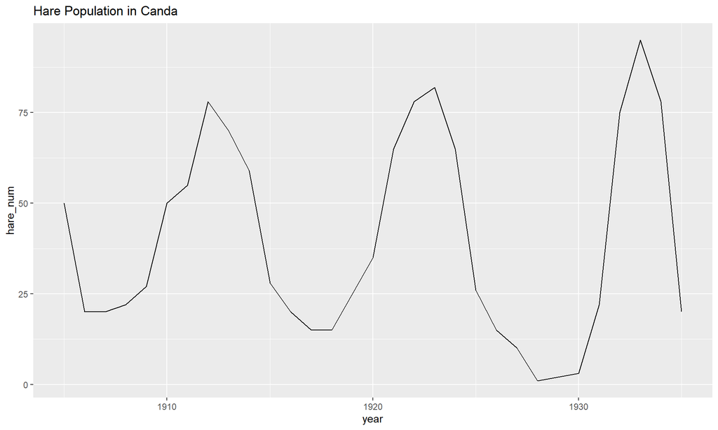

**Exercise 2.** In `R`, read the data from the file sales.csv, that can be downloaded from the Moodle page under datasets. **1.** Transform the data into a time series object of the tsibble type (data are in months and the starting period is January 1992). Print the data.

```
## [1] "C:/Users/emssc/University/2 - Second Semester/Forecasting with Applications in Business/TP 1"
```

```
##   Retail.trade.clothing
## 1                  6938
## 2                  7524
## 3                  8475
## 4                  9401
## 5                  9558
## 6                  9182
```

```
## 'data.frame':    302 obs. of  1 variable:
##  $ Retail.trade.clothing: int  6938 7524 8475 9401 9558 9182 9103 10513 9573 10254 ...
```

```
## [1] 302   1
```

```
## # A tsibble: 302 x 2 [1M]
##       Month Sales
##       <mth> <int>
##  1 1992 Jan  6938
##  2 1992 Feb  7524
##  3 1992 Mar  8475
##  4 1992 Apr  9401
##  5 1992 May  9558
##  6 1992 Jun  9182
##  7 1992 Jul  9103
##  8 1992 Aug 10513
##  9 1992 Sep  9573
## 10 1992 Oct 10254
## # ℹ 292 more rows
```

**2.** Plot the data. Ensure that the y axis starts from zero.[Hint: Use ylim option.]

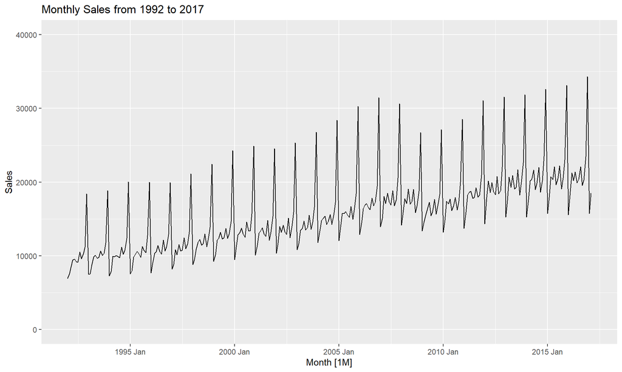

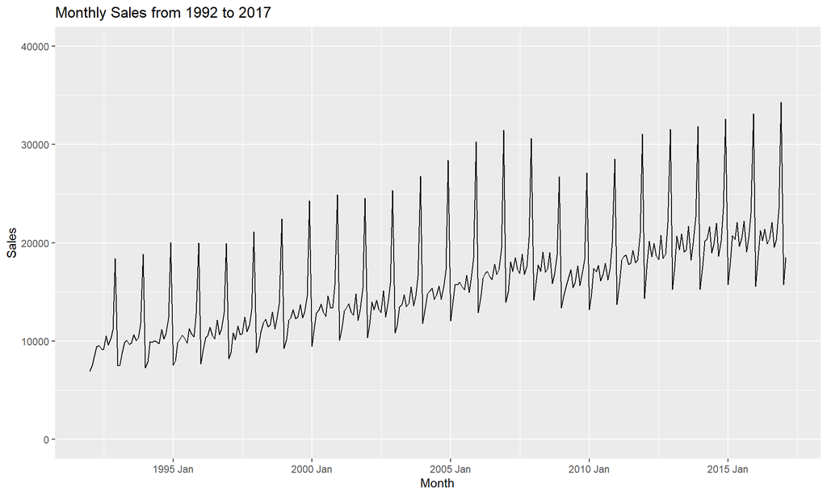

**3.** Use the gghistogram function from the FORECAST package to visually inspect the distribution of time series values. Add a kernel density estimate and a normal density function to the plot.

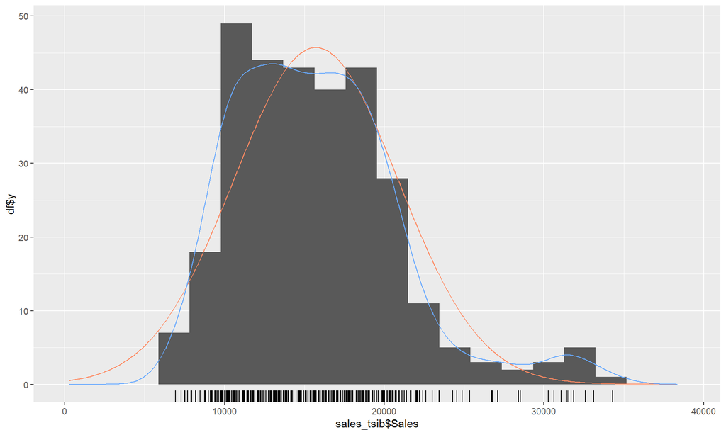

**4.** Decompose the series into seasonal, trend, and random components. Apply additive, multiplicative and STL decomposition. Plot the results.

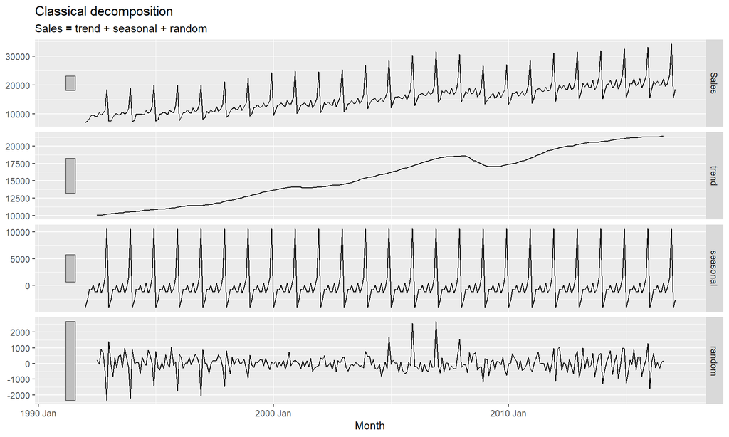

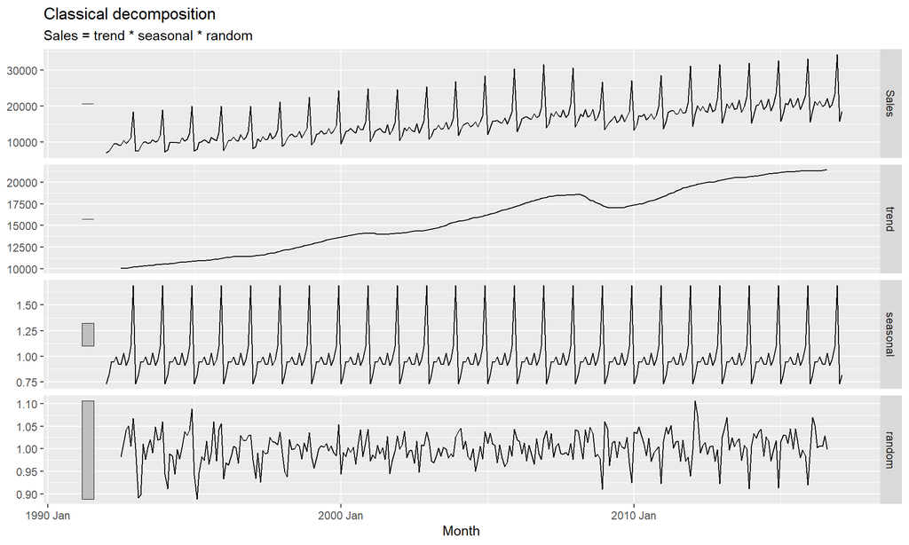

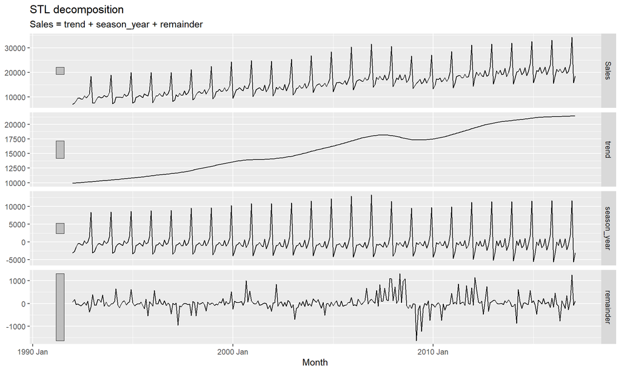

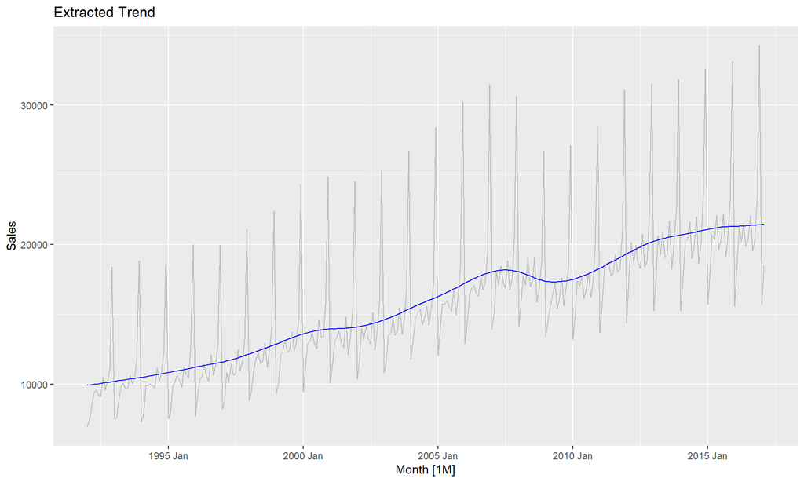

**5.** Explore the structure of the R object built before for the multiplicative decomposition. Find seasonal coefficients. Identify the three months with the greatest coefficients, and the three months with the smallest coefficients.

```
## # A tsibble: 12 x 7 [1M]
## # Key:       .model [1]
##    .model                       Month Sales  trend seasonal random season_adjust
##    <chr>                        <mth> <int>  <dbl>    <dbl>  <dbl>         <dbl>
##  1 "classical_decomposition… 1992 Dec 18395 10180.    1.69   1.07         10868.
##  2 "classical_decomposition… 1992 Nov 11187 10140.    1.10   1.01         10202.
##  3 "classical_decomposition… 1992 Aug 10513 10056.    1.03   1.01         10185.
##  4 "classical_decomposition… 1992 May  9558    NA     0.997 NA             9587.
##  5 "classical_decomposition… 1992 Oct 10254 10099.    0.966  1.05         10611.
##  6 "classical_decomposition… 1992 Mar  8475    NA     0.950 NA             8925.
##  7 "classical_decomposition… 1992 Apr  9401    NA     0.947 NA             9923.
##  8 "classical_decomposition… 1992 Jun  9182    NA     0.925 NA             9927.
##  9 "classical_decomposition… 1992 Jul  9103 10032.    0.925  0.981         9846.
## 10 "classical_decomposition… 1992 Sep  9573 10068.    0.913  1.04         10485.
## 11 "classical_decomposition… 1992 Feb  7524    NA     0.823 NA             9147.
## 12 "classical_decomposition… 1992 Jan  6938    NA     0.733 NA             9461.
```

**6.** Use the same object constructed before to find the trend coefficients. What has been the relative increase from the last to the first level?

```
## # A tsibble: 290 x 2 [1M]
##       Month  trend
##       <mth>  <dbl>
##  1 1992 Jul 10032.
##  2 1992 Aug 10056.
##  3 1992 Sep 10068.
##  4 1992 Oct 10099.
##  5 1992 Nov 10140.
##  6 1992 Dec 10180.
##  7 1993 Jan 10227.
##  8 1993 Feb 10261.
##  9 1993 Mar 10284
## 10 1993 Apr 10306.
## # ℹ 280 more rows
```

```
## [1] 21430.46
```

```
## [1] 10032.08
```

```
## [1] 113.6192
```